# check_collinearity

This function **checks two variables in a dataframe for extreme collinearity**. Given a dataframe and two variables of interest within that dataframe, it returns values of $R^2$, tolerance, and a variance inflation factor (VIF), as well as these values superimposed on a scatterplot showing a linear regression line through the data.

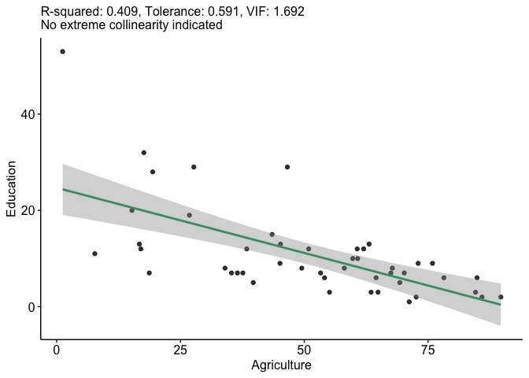

```r
check_collinearity(swiss, 'Agriculture', 'Education')[[4]]
```

# check_outliers

This function **checks a variable in a dataframe for outliers**. The function detects outliers using the MAD-median rule, returns the row indices of those outliers, and also displays a boxplot showing outliers identified according to the (non-robust) boxplot rule.

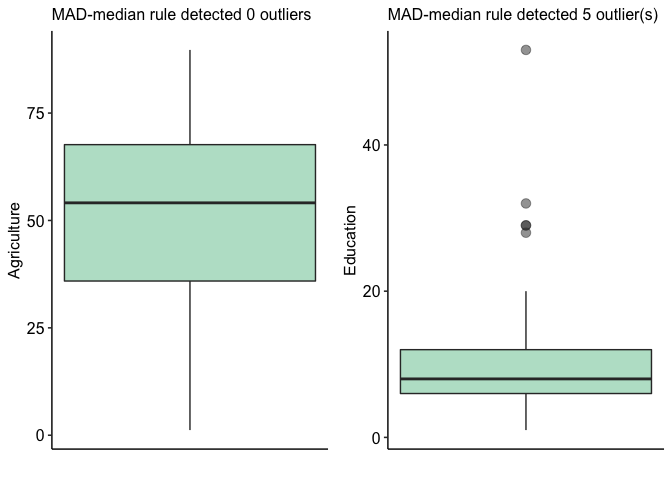

```r
ggpubr::ggarrange(check_outliers(swiss, 'Agriculture')[[2]],
                   check_outliers(swiss, 'Education')[[2]])
```

# check_normality

This function **checks a variable in a dataframe for normality**. The function returns values of skewness, kurtosis, and displays these values along with two plots: a frequency distribution with the mean indicated with a dashed line, and a normal probability plot.

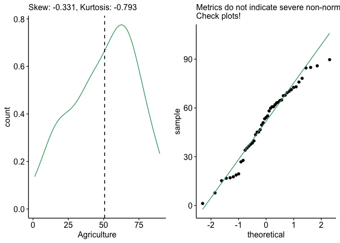

```r
check_normality(swiss, 'Agriculture')[[4]]
```

# create_lm_table

This function **creates a publication-ready table summarizing a linear model fit**. Use this functions if you have fit a linear model in R using the `lm` function and would like to compile the results into a concise set of metrics. To illustrate how to use these functions, I will use data from the `iris` dataset that comes built-in with R:

```
##   Sepal.Length Sepal.Width Petal.Length Petal.Width Species
## 1          5.1         3.5          1.4         0.2  setosa
## 2          4.9         3.0          1.4         0.2  setosa
## 3          4.7         3.2          1.3         0.2  setosa
## 4          4.6         3.1          1.5         0.2  setosa
## 5          5.0         3.6          1.4         0.2  setosa
## 6          5.4         3.9          1.7         0.4  setosa
```

These functions have a few dependencies, which I load below:

```r
library(dplyr)
library(weights)
library(stringr)
library(tidyr)
```

Consider the case of a simple multiple linear regression analysis. For the `iris` dataset, I examine whether petal length and/or petal width are associated with sepal length:

```r
lm.overall <- lm(Sepal.Length ~ Petal.Length + Petal.Width, data = iris)
```

The call to `create_lm_table` below generates a dataframe displaying the coefficients, their standard errors and confidence intervals, and associated *t*- and *p*-values. The first argument is the output of the call to the `lm` function. The second argument `include.intercept = 1` is included to indicate that I would like a row indicating these values for the intercept term. The third argument `vector.of.term.names` allows me to customize the names of the terms that will be displayed in the first column of the dataframe

```r
create_lm_table(lm.object = lm.overall,
                include.intercept = 1,
                vector.of.term.names = c('Intercept', 'Petal Length', 'Petal Width'))
```

```
##      Predictor  Beta    SE         95% CI     t     p
## 1    Intercept 4.191 0.097   4.382, 3.999 43.18 <.001
## 2 Petal Length 0.542 0.069   0.679, 0.405  7.82 <.001
## 3  Petal Width -0.32  0.16 -0.002, -0.637 -1.99  .048
```

The call to `create_lm_summary` below generates a string summarizing the fit of the regression model. This function takes only one argument, the output of the call to the `lm` function:

```r
create_lm_summary(lm.object = lm.overall)
```

```
## [1] "F(2, 147) = 240.95, p < .001, R^2 = 0.766, adjusted R^2 = 0.763"
```

Finally, I use the `kableExtra` package to combine these outputs into a single, publication-ready table:

```r
library(kableExtra)
table_overall <- create_lm_table(lm.object = lm.overall,
                                 include.intercept = 1,
                                 vector.of.term.names = c('Intercept', 'Petal Length', 'Petal Width'))
kable(table_overall) %>%
  kable_styling(full_width = F,
                'striped',
                position = 'left') %>%
  pack_rows(str_c(create_lm_summary(lm.object = lm.overall)),
            1, nrow(table_overall))
```

| Predictor | Beta | SE | 95% CI | t | p |
| --- | --- | --- | --- | --- | --- |
| **F(2, 147) = 240.95, p < .001, R^2 = 0.766, adjusted R^2 = 0.763** |  |  |  |  |  |
| Intercept | 4.191 | 0.097 | 4.382, 3.999 | 43.18 | <.001 |
| Petal Length | 0.542 | 0.069 | 0.679, 0.405 | 7.82 | <.001 |
| Petal Width | -0.32 | 0.16 | -0.002, -0.637 | -1.99 | .048 |

Next, I consider the case of a regression analysis with multiple groups, where I might want to create a table in which coefficients, etc. for each group are stacked on top of one another. I use the `iris` dataset again, this time performing a separate regression of petal length and width on sepal length, for each iris species separately:

```r
lm.setosa <- lm(Sepal.Length ~ Petal.Length + Petal.Width, data = iris %>% filter(Species == 'setosa'))
lm.versicolor <- lm(Sepal.Length ~ Petal.Length + Petal.Width, data = iris %>% filter(Species == 'versicolor'))
lm.virginica <- lm(Sepal.Length ~ Petal.Length + Petal.Width, data = iris %>% filter(Species == 'virginica'))
```

I consolidate the steps above to create a single, composite table summarizing the output of all three model fits:

```r
table_setosa <- create_lm_table(lm.object = lm.setosa,
                                 include.intercept = 1,
                                 vector.of.term.names = c('Intercept', 'Petal Length', 'Petal Width'))
table_versicolor <- create_lm_table(lm.object = lm.versicolor,
                                 include.intercept = 1,
                                 vector.of.term.names = c('Intercept', 'Petal Length', 'Petal Width'))
table_virginica <- create_lm_table(lm.object = lm.virginica,
                                 include.intercept = 1,
                                 vector.of.term.names = c('Intercept', 'Petal Length', 'Petal Width'))

kable(as.data.frame(rbind(table_setosa,
                          table_versicolor,
                          table_virginica))) %>%
  kable_styling(full_width = F, 'striped', position = 'left') %>%
  pack_rows(str_c('Setosa, ', create_lm_summary(lm.object = lm.setosa), sep = ''), 1, nrow(table_setosa)) %>%
  pack_rows(str_c('Versicolor, ', create_lm_summary(lm.object = lm.versicolor), sep = ''), nrow(table_setosa)+1, nrow(table_setosa)+nrow(table_versicolor)) %>%
  pack_rows(str_c('Virginica, ', create_lm_summary(lm.object = lm.virginica), sep = ''), nrow(table_setosa)+nrow(table_versicolor)+1, nrow(table_setosa)+nrow(table_versicolor)+nrow(table_virginica))
```

| Predictor | Beta | SE | 95% CI | t | p |
| --- | --- | --- | --- | --- | --- |
| **Setosa, F(2, 47) = 2.96, p = , R^2 = 0.112, adjusted R^2 = 0.074** |  |  |  |  |  |
| Intercept | 4.248 | 0.411 | 5.075, 3.42 | 10.32 | <.001 |
| Petal Length | 0.399 | 0.296 | 0.994, -0.196 | 1.35 | .184 |
| Petal Width | 0.712 | 0.487 | 1.693, -0.268 | 1.46 | .151 |
| **Versicolor, F(2, 47) = 31.71, p < .001, R^2 = 0.574, adjusted R^2 = 0.556** |  |  |  |  |  |
| Intercept | 2.381 | 0.449 | 3.284, 1.477 | 5.3 | <.001 |
| Petal Length | 0.934 | 0.169 | 1.275, 0.594 | 5.52 | <.001 |
| Petal Width | -0.32 | 0.402 | 0.489, -1.129 | -0.8 | .430 |
| **Virginica, F(2, 47) = 69.35, p < .001, R^2 = 0.747, adjusted R^2 = 0.736** |  |  |  |  |  |
| Intercept | 1.052 | 0.514 | 2.085, 0.018 | 2.05 | .046 |
| Petal Length | 0.995 | 0.089 | 1.174, 0.815 | 11.14 | <.001 |
| Petal Width | 0.007 | 0.179 | 0.368, -0.354 | 0.04 | .969 |